# Model

In this notebook we'll attempt to test and benchmark various models, their parameters and preprocessing techniques which can be used to predict the target variables like 'Quality' and 'Alcohol Content'.

```
quality
1    681
2    638
3    217
0     63
Name: count, dtype: int64
```

Well start by trying to predict 'alcohol' and 'quality' with these models using their default parameters:

- Stochastic Gradient Descent
- ElasticNet
- LogisticRegression
- Random Forest
- XGBoost
- Logistic Regression

Additionally we'll test these preprocessing techniques: - None - Standardization - Standardization + PCA with 2 to (Features Count - 1) components

```
{0: 6.345238095238095,
 1: 0.5870044052863436,
 2: 0.6265673981191222,
 3: 1.8421658986175116}
```

Predicting Quality: Model Benchmark

|  | Model | Preprocessors | f1 | accuracy | precision | recall |
| --- | --- | --- | --- | --- | --- | --- |
| 52 | MRandomForestClassifier (classifier) {'random_state': 42} | DataBalancer f{"sampling_strategy": {"0": 100, "3": 300}, "random_state": 42},Scaler f{} | 0.6422 | 0.7053 | 0.6711 | 0.6309 |
| 78 | MRandomForestClassifier (classifier) {'random_state': 42} | DataBalancer f{"sampling_strategy": {"0": 200}, "random_state": 42},Scaler f{},PCA f{"n_components": 5} | 0.6330 | 0.7022 | 0.6376 | 0.6299 |
| 83 | MRandomForestClassifier (classifier) {'random_state': 42} | DataBalancer f{"sampling_strategy": {"0": 100, "3": 300}, "random_state": 42},Scaler f{},PCA f{"n_components": 9} | 0.6261 | 0.7147 | 0.6826 | 0.6096 |
| 53 | MRandomForestClassifier (classifier) {'random_state': 42} | DataBalancer f{"sampling_strategy": {"0": 100, "3": 300}, "random_state": 42} | 0.6214 | 0.7053 | 0.6537 | 0.6120 |
| 82 | MRandomForestClassifier (classifier) {'random_state': 42} | DataBalancer f{"sampling_strategy": {"0": 100}, "random_state": 42},Scaler f{},PCA f{"n_components": 9} | 0.6195 | 0.7085 | 0.7015 | 0.5837 |
| 76 | MRandomForestClassifier (classifier) {'random_state': 42} | DataBalancer f{"sampling_strategy": {"0": 150, "3": 300}, "random_state": 42},Scaler f{},PCA f{"n_components": 5} | 0.6183 | 0.6991 | 0.6171 | 0.6273 |
| 39 | XGBClassifier (classifier) {'random_state': 42} | Scaler f{},PCA f{"n_components": 9} | 0.6142 | 0.7179 | 0.7149 | 0.5898 |
| 28 | XGBClassifier (classifier) {'random_state': 42} | DataBalancer f{"sampling_strategy": {"0": 200}, "random_state": 42},Scaler f{},PCA f{"n_components": 5} | 0.6139 | 0.6834 | 0.6126 | 0.6182 |
| 59 | MRandomForestClassifier (classifier) {'random_state': 42} | DataBalancer f{"sampling_strategy": {"0": 200}, "random_state": 42} | 0.6134 | 0.6865 | 0.6349 | 0.5972 |
| 40 | MRandomForestClassifier (classifier) {'class_weight': 'balanced', 'random_state': 42} | Scaler f{} | 0.6128 | 0.7147 | 0.7100 | 0.5913 |

```
{'Model': "LogisticRegression (classifier) {'random_state': 42}",
 'Preprocessors': 'DataBalancer f{"sampling_strategy": {"0": 100, "3": 300}, "random_state": 42},Scaler f{},PCA f{"n_components": 9}',
 'f1': 0.5595,
 'accuracy': 0.6301,
 'precision': 0.6396,
 'recall': 0.5538}
```

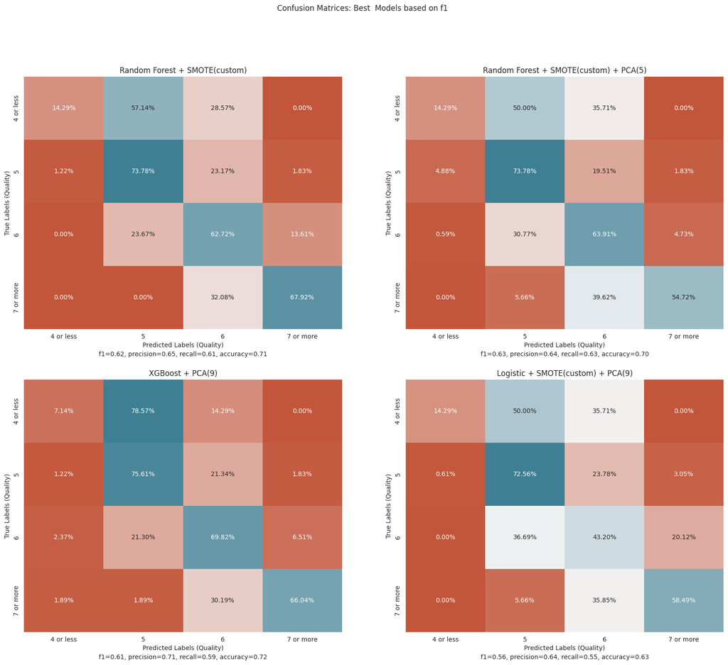

##### Selected models:

- Best Overall (RF + SMOTE)
- Best With PCA (RF + SMOTE + PCA(5)
- Best XGBoost (PCA(9))
- Best Logistic

XGBoost is more accurate at predicting the middle classes with poorer results for the bottom/top classes.

Overall none of the model provide good result. Even when using various balancing techniques like SMOTE (in this case the best results were achieved by manually specifying sampling strategy for the underrepresented classes) they still strong struggle to detect the classes which are underrepresented in the initial dataset. This indicates that either/both:

- there is not enough data in the dataset for the lowest/highest quality wines to build a robust model
- quality scores are assigned arbitrarily/using other data not included in the dataset and the chemical properties dataset can't be used to distinguish wines which have similar quality rating.

Based on this we can try and simplify our objective by just trying to predict high vs low quality wines instead of the exact quality score.

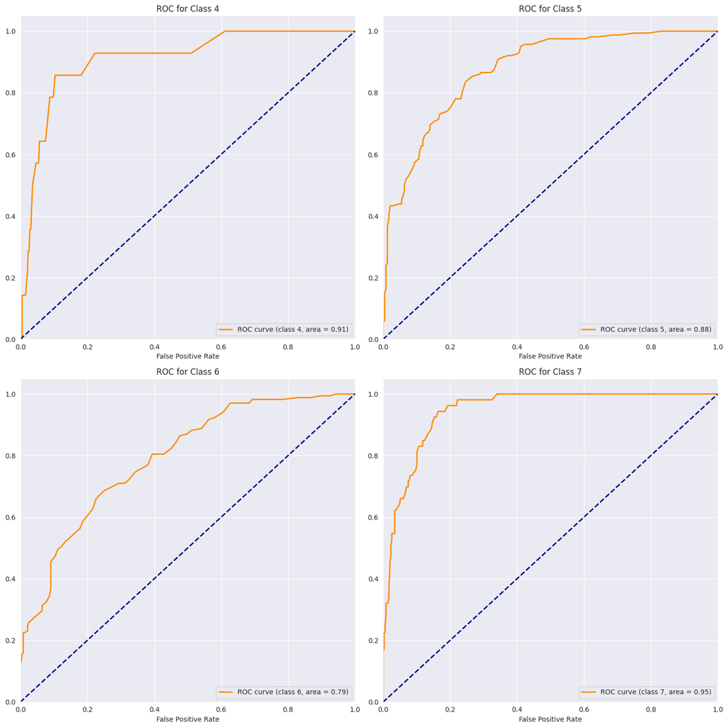

#### Binary Classification

To achieve our initial objective (designing a model which could be used by wine merchants to select high quality wines) we don't really need to determine its exact `quality` rating, just determine whether the wine is "good" would be enough.

To accomplish that we'll binarize the `quality` rating defined as wines which have a `quality` higher than 6 as good:

```
quality_over_7_or_more
0    1382
1     217
Name: count, dtype: int64
```

We can see that the dataset is heavily imbalanced, so we'll apply the balancing techniques (SMOTE or Class Weighting) we have used previously:

Predicting Binary Quality: Model Benchmark

(Quality > 6)

|  | Model | Preprocessors | f1 | accuracy | precision | recall |
| --- | --- | --- | --- | --- | --- | --- |
| 65 | MRandomForestClassifier (classifier) {'random_state': 42} | DataBalancer f{"sampling_strategy": {"1": 400}, "random_state": 42},Scaler f{},PCA f{"n_components": 9} | 0.8203 | 0.9154 | 0.8173 | 0.8235 |
| 4 | XGBClassifier (classifier) {'random_state': 42} | DataBalancer f{"sampling_strategy": {"1": 600}, "random_state": 42},Scaler f{} | 0.8142 | 0.9091 | 0.8008 | 0.8297 |
| 5 | XGBClassifier (classifier) {'random_state': 42} | DataBalancer f{"sampling_strategy": {"1": 600}, "random_state": 42} | 0.8142 | 0.9091 | 0.8008 | 0.8297 |
| 29 | XGBClassifier (classifier) {'random_state': 42} | Scaler f{},PCA f{"n_components": 9} | 0.8091 | 0.9154 | 0.8268 | 0.7940 |
| 44 | MRandomForestClassifier (classifier) {'random_state': 42} | DataBalancer f{"sampling_strategy": {"1": 600}, "random_state": 42},Scaler f{} | 0.8013 | 0.9028 | 0.7885 | 0.8162 |
| 34 | MRandomForestClassifier (classifier) {'class_weight': 'balanced', 'random_state': 42} | Scaler f{},PCA f{"n_components": 9} | 0.8013 | 0.9185 | 0.8541 | 0.7664 |
| 45 | MRandomForestClassifier (classifier) {'random_state': 42} | DataBalancer f{"sampling_strategy": {"1": 600}, "random_state": 42} | 0.8013 | 0.9028 | 0.7885 | 0.8162 |
| 7 | XGBClassifier (classifier) {'random_state': 42} | DataBalancer f{"sampling_strategy": {"1": 800}, "random_state": 42} | 0.8004 | 0.8997 | 0.7815 | 0.8242 |
| 6 | XGBClassifier (classifier) {'random_state': 42} | DataBalancer f{"sampling_strategy": {"1": 800}, "random_state": 42},Scaler f{} | 0.8004 | 0.8997 | 0.7815 | 0.8242 |
| 3 | XGBClassifier (classifier) {'random_state': 42} | DataBalancer f{"sampling_strategy": {"1": 400}, "random_state": 42} | 0.7992 | 0.9091 | 0.8088 | 0.7904 |
| 2 | XGBClassifier (classifier) {'random_state': 42} | DataBalancer f{"sampling_strategy": {"1": 400}, "random_state": 42},Scaler f{} | 0.7992 | 0.9091 | 0.8088 | 0.7904 |
| 66 | MRandomForestClassifier (classifier) {'random_state': 42} | DataBalancer f{"sampling_strategy": {"1": 600}, "random_state": 42},Scaler f{},PCA f{"n_components": 9} | 0.7984 | 0.8934 | 0.7704 | 0.8402 |
| 43 | MRandomForestClassifier (classifier) {'random_state': 42} | DataBalancer f{"sampling_strategy": {"1": 400}, "random_state": 42} | 0.7984 | 0.9060 | 0.7984 | 0.7984 |
| 39 | MRandomForestClassifier (classifier) {'class_weight': 'balanced_subsample', 'random_state': 42} | Scaler f{},PCA f{"n_components": 9} | 0.7965 | 0.9185 | 0.8621 | 0.7566 |
| 10 | XGBClassifier (classifier) {'random_state': 42} | Scaler f{} | 0.7955 | 0.9122 | 0.8255 | 0.7726 |
| 11 | XGBClassifier (classifier) {'random_state': 42} |  | 0.7955 | 0.9122 | 0.8255 | 0.7726 |
| 67 | MRandomForestClassifier (classifier) {'random_state': 42} | DataBalancer f{"sampling_strategy": {"1": 800}, "random_state": 42},Scaler f{},PCA f{"n_components": 9} | 0.7932 | 0.8871 | 0.7612 | 0.8464 |
| 59 | MRandomForestClassifier (classifier) {'random_state': 42} | DataBalancer f{"sampling_strategy": {"1": 400}, "random_state": 42},Scaler f{},PCA f{"n_components": 5} | 0.7930 | 0.8997 | 0.7828 | 0.8046 |
| 31 | MRandomForestClassifier (classifier) {'class_weight': 'balanced', 'random_state': 42} |  | 0.7912 | 0.9154 | 0.8487 | 0.7548 |
| 63 | MRandomForestClassifier (classifier) {'random_state': 42} | Scaler f{},PCA f{"n_components": 5} | 0.7912 | 0.9154 | 0.8487 | 0.7548 |
| 26 | XGBClassifier (classifier) {'random_state': 42} | DataBalancer f{"sampling_strategy": {"1": 600}, "random_state": 42},Scaler f{},PCA f{"n_components": 9} | 0.7865 | 0.8871 | 0.7597 | 0.8268 |
| 69 | MRandomForestClassifier (classifier) {'random_state': 42} | Scaler f{},PCA f{"n_components": 9} | 0.7860 | 0.9122 | 0.8362 | 0.7529 |
| 30 | MRandomForestClassifier (classifier) {'class_weight': 'balanced', 'random_state': 42} | Scaler f{} | 0.7860 | 0.9122 | 0.8362 | 0.7529 |
| 89 | LogisticRegression (classifier) {'random_state': 42} | DataBalancer f{"sampling_strategy": {"1": 400}, "random_state": 42},Scaler f{},PCA f{"n_components": 5} | 0.7858 | 0.8840 | 0.7557 | 0.8348 |
| 42 | MRandomForestClassifier (classifier) {'random_state': 42} | DataBalancer f{"sampling_strategy": {"1": 400}, "random_state": 42},Scaler f{} | 0.7850 | 0.8997 | 0.7850 | 0.7850 |
| 9 | XGBClassifier (classifier) {'random_state': 42} | DataBalancer f{"sampling_strategy": {"1": 1000}, "random_state": 42} | 0.7846 | 0.8966 | 0.7769 | 0.7930 |
| 8 | XGBClassifier (classifier) {'random_state': 42} | DataBalancer f{"sampling_strategy": {"1": 1000}, "random_state": 42},Scaler f{} | 0.7846 | 0.8966 | 0.7769 | 0.7930 |
| 46 | MRandomForestClassifier (classifier) {'random_state': 42} | DataBalancer f{"sampling_strategy": {"1": 800}, "random_state": 42},Scaler f{} | 0.7841 | 0.8934 | 0.7700 | 0.8010 |
| 64 | MRandomForestClassifier (classifier) {'random_state': 42} | DataBalancer f{"random_state": 42},Scaler f{},PCA f{"n_components": 9} | 0.7810 | 0.8777 | 0.7480 | 0.8410 |
| 33 | MRandomForestClassifier (classifier) {'class_weight': 'balanced', 'random_state': 42} | Scaler f{},PCA f{"n_components": 5} | 0.7809 | 0.9091 | 0.8245 | 0.7511 |

[output cut: 70 more lines]

We can see that the results are considerably better with both RF and XGBoost offering decent precision and recall scores:

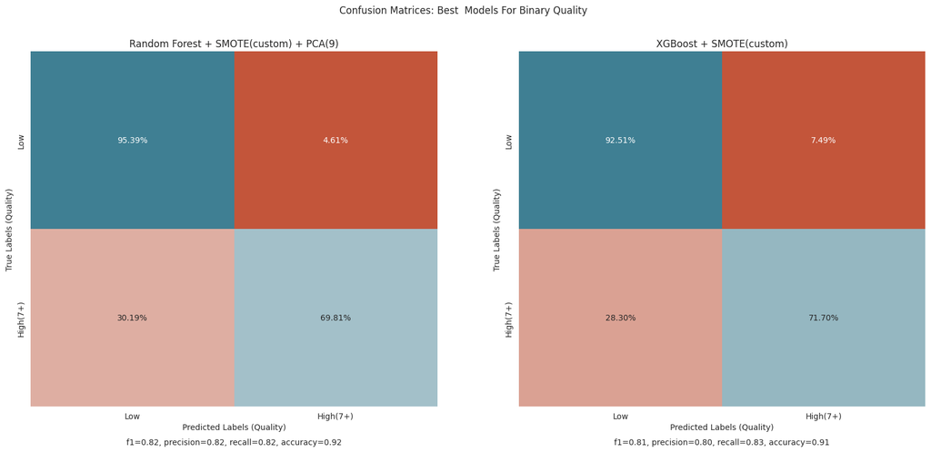

Unfortunately both RF and XGBoost still struggle to correctly classify high quality wines with about ~30% of them classified as low quality. However, relatively few low quality wines are misclassified as high the models might still be suitable for our goals. While this is not really fair to those winemakers whose high quality wines are excluded a bigger concern from the meechant/distributors perspective would be accidentally buying too many poor wines.

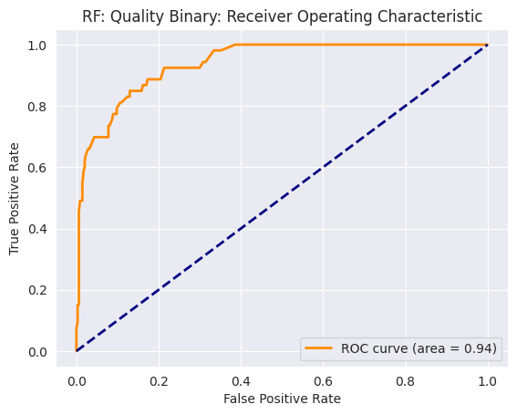

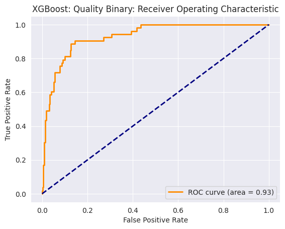

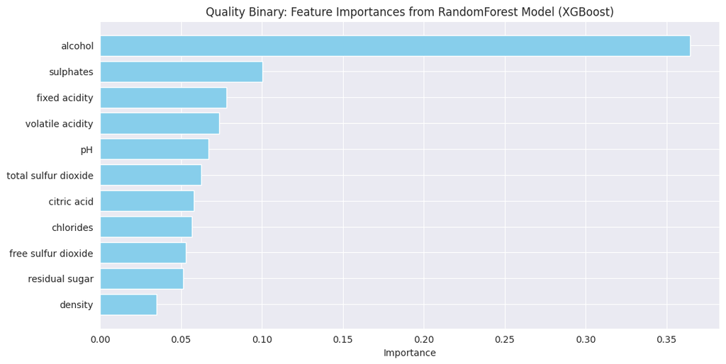

Predicting Alcohol: Model Benchmark

Quality Included:

|  | Model | Preprocessors | MSE | MAE | R2 |
| --- | --- | --- | --- | --- | --- |
| 2 | XGBRegressor (regression) {'random_state': 42} | Scaler f{} | 0.2418 | 0.3143 | 0.7805 |
| 3 | XGBRegressor (regression) {'random_state': 42} |  | 0.2418 | 0.3143 | 0.7805 |
| 0 | RandomForestRegressor (regression) {'random_state': 42} | Scaler f{} | 0.2486 | 0.3477 | 0.7743 |
| 1 | RandomForestRegressor (regression) {'random_state': 42} |  | 0.2486 | 0.3489 | 0.7743 |
| 5 | ElasticNet (regression) {'alpha': 1.0, 'l1_ratio': 0.5, 'random_state': 42} |  | 1.0416 | 0.7961 | 0.0546 |
| 4 | ElasticNet (regression) {'alpha': 1.0, 'l1_ratio': 0.5, 'random_state': 42} | Scaler f{} | 1.0934 | 0.8362 | 0.0076 |
| 6 | MeanPredictor (regression) {} | Scaler f{} | 1.1183 | 0.8428 | -0.0150 |
| 7 | MeanPredictor (regression) {} |  | 1.1183 | 0.8428 | -0.0150 |

Quality Excluded:

|  | Model | Preprocessors | MSE | MAE | R2 |
| --- | --- | --- | --- | --- | --- |
| 0 | RandomForestRegressor (regression) {'random_state': 42} | Scaler f{} | 0.2605 | 0.3625 | 0.7636 |
| 1 | RandomForestRegressor (regression) {'random_state': 42} |  | 0.2605 | 0.3628 | 0.7635 |
| 2 | XGBRegressor (regression) {'random_state': 42} | Scaler f{} | 0.2773 | 0.3580 | 0.7483 |
| 3 | XGBRegressor (regression) {'random_state': 42} |  | 0.2773 | 0.3580 | 0.7483 |
| 5 | ElasticNet (regression) {'alpha': 1.0, 'l1_ratio': 0.5, 'random_state': 42} |  | 1.0416 | 0.7961 | 0.0546 |
| 4 | ElasticNet (regression) {'alpha': 1.0, 'l1_ratio': 0.5, 'random_state': 42} | Scaler f{} | 1.0934 | 0.8362 | 0.0076 |
| 6 | MeanPredictor (regression) {} | Scaler f{} | 1.1183 | 0.8428 | -0.0150 |
| 7 | MeanPredictor (regression) {} |  | 1.1183 | 0.8428 | -0.0150 |

Our next step is trying to predict alcohol content using other chemical properties. In this case we'll use regression instead of classification models and therefore will have to use different metrics to rank them.

We can see that even when quality is excluded we still ge reasonably good results:

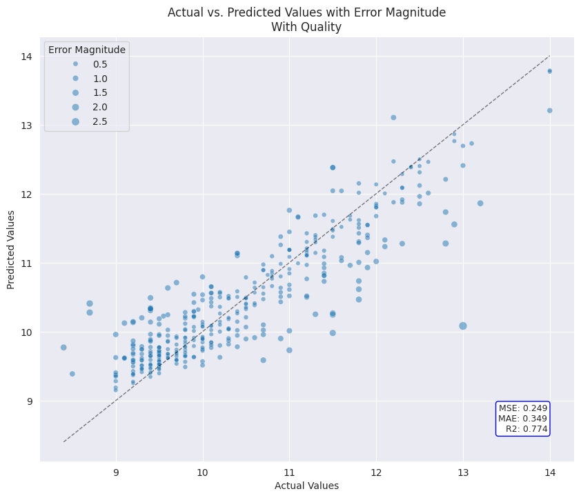

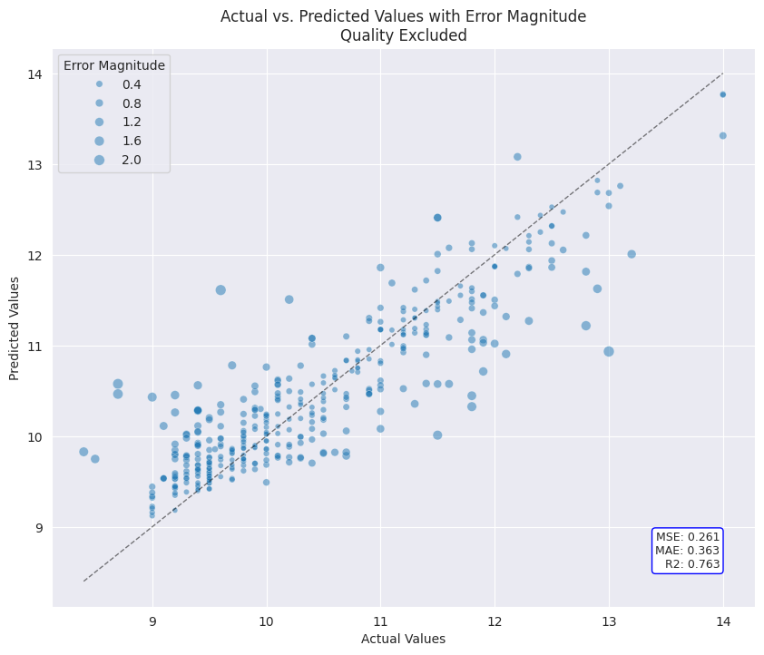

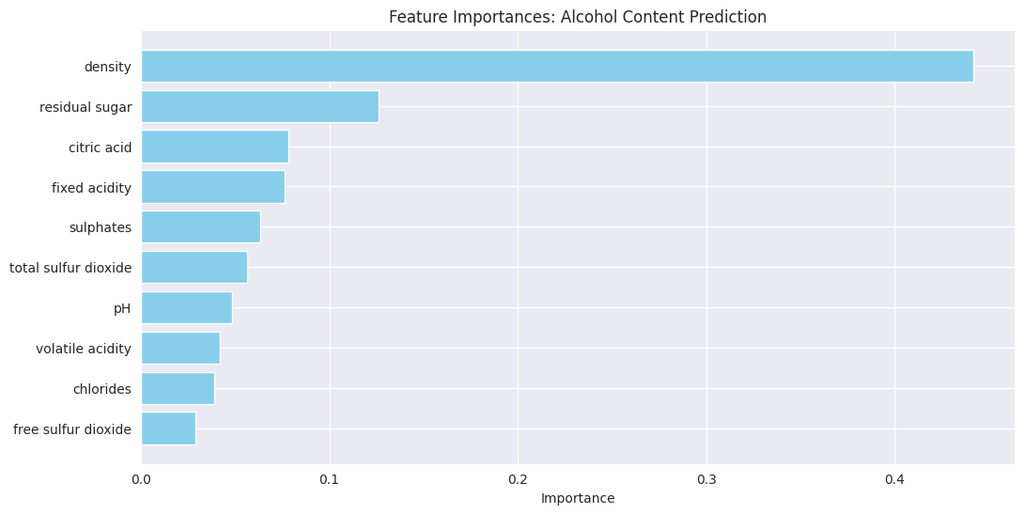